# biostat Hist pred

francois bettega

01/12/2019

```r
knitr::opts_chunk$set(echo = TRUE, warning = FALSE,message = FALSE)
library(tidyverse)
library(knitr)
library(caret)
library(glmnet)
library(randomForest)
library(doParallel)

# récupérations de la formule depuis un model
formule <- function(x,str_r){
  a <- as.character(x)
  b <- str_remove_all(a,str_r)
  c <- paste0(b[2],b[1],b[3])
  return(c)
}

# recupération de la formule avec le noms des gènes
forule_to_name <- function(formulee){
colonne <- as.numeric(str_extract_all(formulee,"[:digit:]+")[[1]])
nom <- gs[colonne]
return(nom)
}

# fonction de pred pour model classique
out <- function(model,arg_nom){
test <- readRDS("data_test_histology.rds")
test[,c(2:4,8:12)] <- lapply(test[,c(2:4,8:12)],as.factor)
test[,c(6,7)] <- lapply(test[,c(6,7)],function(x) x=="true") # transformation des chr booléen en booléen
test <- test %>% select(- tissue_status,- tnm_grade) #retrait de 2 colones n'apportant pas d'informations
names(test)[11:1010] <- as.character(c(11:1010)) #pourfaciliter l'utilisation de formule
pred <- predict.glm(object = model, newdata = test, type = "response")
idx  <- pred >= 0.5
pred[  idx ] <- levels(x = d$histology)[ 1 ]
pred[ !idx ] <- levels(x = d$histology)[ 2 ]
table(pred, useNA = "ifany")
saveRDS(pred, "results.rds")
zip_filename <- paste0(
    "results/results_"
  , format(x = Sys.time( ), format = "%Y_%m_%d_-_%s")
  , "_" ,arg_nom
  , ".zip"
)
if ( !{ "zip" %in% installed.packages( ) } ) {
    install.packages(pkgs = "zip")
}
zip::zip(zip_filename, "results.rds")
print(zip_filename)
}

# out pour ramdom for et ela_net
out2 <- function(model,arg_nom){
test <- readRDS("data_test_histology.rds")
test[,c(2:4,8:12)] <- lapply(test[,c(2:4,8:12)],as.factor)
test[,c(6,7)] <- lapply(test[,c(6,7)],function(x) x=="true") # transformation des chr booléen en booléen
test <- test %>% select(- tissue_status,- tnm_grade) #retrait de 2 colones n'apportant pas d'informations
names(test)[11:1010] <- as.character(c(11:1010)) #pourfaciliter l'utilisation de formule
pred <- predict(object = model, newdata = test, type = "prob")
idx  <- apply(pred,1, function(x) which(max(x)==x))
res <- numeric(length(idx))
names(res) <- rownames(test)
res[idx==2] <- levels(x = d$histology)[ 1 ]
res[ idx==1] <- levels(x = d$histology)[ 2 ]
table(res, useNA = "ifany")
saveRDS(res, "results.rds")
zip_filename <- paste0(
    "results/results_"
  , format(x = Sys.time( ), format = "%Y_%m_%d_-_%s")
  , "_" ,arg_nom
  , ".zip"
)
if ( !{ "zip" %in% installed.packages( ) } ) {
    install.packages(pkgs = "zip")
}
zip::zip(zip_filename, "results.rds")
print(zip_filename)
}

# out pour SVM
outsvm <- function(model,arg_nom){
test <- readRDS("data_test_histology.rds")
test[,c(2:4,8:12)] <- lapply(test[,c(2:4,8:12)],as.factor)
test[,c(6,7)] <- lapply(test[,c(6,7)],function(x) x=="true") # transformation des chr booléen en booléen
test <- test %>% select(- tissue_status,- tnm_grade) #retrait de 2 colones n'apportant pas d'informations
names(test)[11:1010] <- as.character(c(11:1010)) #pourfaciliter l'utilisation de formule
pred <- as.numeric(predict(object = model, newdata = test))
names(pred) <- rownames(test)
pred[pred==2] <- levels(x = d$histology)[ 1 ]
pred[pred==1 ] <- levels(x = d$histology)[ 2 ]
table(pred, useNA = "ifany")
saveRDS(pred, "results.rds")
zip_filename <- paste0(
    "results/results_"
  , format(x = Sys.time( ), format = "%Y_%m_%d_-_%s")
  , "_" ,arg_nom
  , ".zip"
)
if ( !{ "zip" %in% installed.packages( ) } ) {
    install.packages(pkgs = "zip")
}
zip::zip(zip_filename, "results.rds")
print(zip_filename)
}

#variable pour la parélisations
cl <- makePSOCKcluster(6)
```

The data set ‘data_learn.rds’ is composed of the following information :

```r
d = readRDS(file="data_learn.rds")
gs = names(d)[13:1012]

d[,c(2:4,8:12)] <- lapply(d[,c(2:4,8:12)],as.factor)

d[,c(6,7)] <- lapply(d[,c(6,7)],function(x) x=="true") # transformation des chr booléen en booléen

d_to_summary <- d

d <- d %>% select(- tissue_status,- tnm_grade) #retrait de 2 colones n'apportant pas d'informations

names(d)[11:1010] <- as.character(c(11:1010)) #pourfaciliter l'utilisation de formule

gs_num <- as.character(c(11:1010))
# gène considéré comme 1 TCGA-LUSC
histo <- as.numeric(d$histology == "TCGA-LUAD")
```

# Objectif

L’objectif de ce rapport et d’évaluer une liste de caractère : - Biological attributes are: age, sex, histology. - Histological attribuites are: tissue_status - Clinical attributes are: os_months, dead, dead_at_24_months, t, n, m, tnm_stage, tnm_grade - Ainsi que des niveau d’expression de certains gène.

```r
kable(summary(d_to_summary[1:6]), digits=2)
```

|  | age | sex | tissue_status | histology | os_months | dead |
| --- | --- | --- | --- | --- | --- | --- |
|  | Min. :38.53 | F:223 | tumoral:546 | TCGA-LUAD:273 | Min. : 0.00 | Mode :logical |
|  | 1st Qu.:60.48 | M:323 | NA | TCGA-LUSC:273 | 1st Qu.: 11.91 | FALSE:348 |
|  | Median :67.42 | NA | NA | NA | Median : 20.87 | TRUE :198 |
|  | Mean :66.42 | NA | NA | NA | Mean : 29.59 | NA |
|  | 3rd Qu.:73.18 | NA | NA | NA | 3rd Qu.: 37.45 | NA |
|  | Max. :88.85 | NA | NA | NA | Max. :241.60 | NA |

```r
kable(summary(d_to_summary[7:12]), digits=2)
```

|  | dead_at_24_months | t | n | m | tnm_stage | tnm_grade |
| --- | --- | --- | --- | --- | --- | --- |
|  | Mode :logical | T2 :162 | N0 :359 | M0 :400 | IB :152 | NA’s:546 |
|  | FALSE:231 | T2a :102 | N1 :113 | M1 : 13 | IA :119 | NA |
|  | TRUE :112 | T3 : 67 | N2 : 64 | M1a : 2 | IIB : 88 | NA |
|  | NA’s :203 | T1 : 55 | N3 : 2 | M1b : 3 | IIIA : 76 | NA |
|  | NA | T1b : 51 | NX : 7 | MX :122 | IIA : 55 | NA |
|  | NA | T1a : 40 | NA’s: 1 | NA’s: 6 | (Other): 46 | NA |
|  | NA | (Other): 69 | NA | NA | NA’s : 10 | NA |

Le tableau ci-dessus présente les statistiques descriptives pour les variables biologiques histologiques et cliniques. À la vue de ce tableau, nous avons choisi comme prétraitement et pour des questions de lisibilité de retirer deux colonnes n’apportant pas d’information. Le statut, tumoral ou non tumoral , du tissu ne nous a pas apporté d’information, tous nos individus étant des échantillons de tissus cancéreux. Nous avons aussi retiré le grade_tnm qui n’était pas renseigné.

De plus nous pouvons constater que les colones dead_at_24_months,n,m est tnm_stage contienne des valeurs manquantes il faudra résoudre cette problématique avant de les intégrer a nos modèles

toutes ces variables seront utilisées comme prédicateur du type histologique des tissus cancéreux, notre modèle vise à prédire entre deux types de cancer du poumon : l’adénocarcinome pulmonaire et les carcinomes épidermoïdes du poumon

Pour des questions de temps lors de notre recherche de modèle nous ne nous attarderons uniquement sur la signification biologique des gènes utilisés comme variable dans le modèle obtenant le meilleur score.

Durant notre exploration des différents modèles utilisable pour prédire le type histologique du cancer. Nous utiliserons pour le choix d’hyper paramètres un cross validation à 10 folds.

# Approche initiale basé sur le cours

## Modele naïf

Pour commencer, nous avons essayé le modèle naïf de prédiction de la classe majoritaire pour définir une performance de base pour nos modèles à venir.

Dans le cas présent il n’y avait pas de classe majoritaire, nous avons donc choisi de prédire une classe au hasard.

```r
arg_nom <- "naif"
idx  <- rep(0,100)
pred <- numeric()
pred[  idx ] <- levels(x = d$histology)[ 1 ]
pred[ !idx ] <- levels(x = d$histology)[ 2 ]
saveRDS(pred, "results.rds")
zip_filename <- paste0(
   "results/results_"
  , format(x = Sys.time( ), format = "%Y_%m_%d_-_%s")
  , "_" ,arg_nom
  , ".zip"
)
if ( !{ "zip" %in% installed.packages( ) } ) {
    install.packages(pkgs = "zip")
}
zip::zip(zip_filename, "results.rds")
print(zip_filename)
```

```
## [1] "results/results_2019_12_02_-_1575281955_naif.zip"
```

## Modele utilisant volcano plot et AIC “step wise”

### un model lineaire par gène

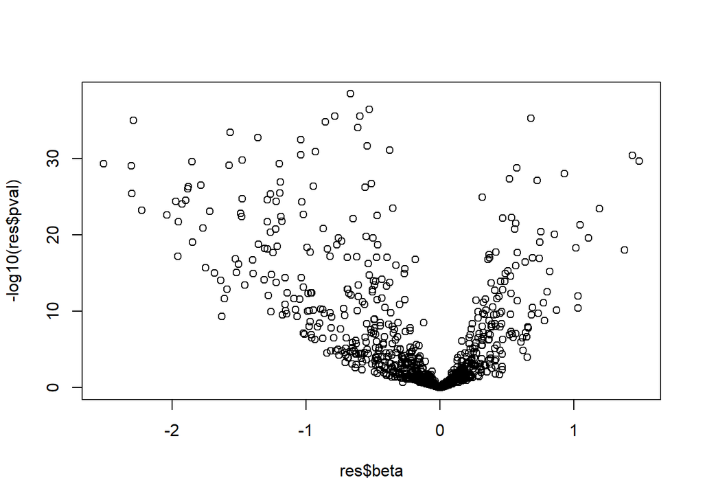

```r
res = sapply(gs_num, function(g) {
  m = glm(c(histo,0,0,1,1)~c(d[[g]],0,max(d[,gs_num]),0,max(d[,gs_num])),
    family = binomial(logit))
  b = m$coefficients[[2]]
  pv = summary(m)$coefficients[2,4]
  c(pval = pv,beta = b)
})

res = t(res)
res = as.data.frame(res)


plot(res$beta,-log10(res$pval))
```

Comme nous avons beaucoup de gènes, il est impossible de savoir juste sur le graphique quel gène sélectionner. Un problème que nous pourrions rencontrer et qu’énormément de gènes semblent avoir des P-valeur très faibles (inférieur a $\leq 10^{-10}$). Il semble raisonnable en se basant sur ce graphique de choisir les critères suivant pour sélectionner les gènes les plus pertinents : $|\beta|\geq 0.5$ et $P-val\leq 10^{-20}$

```r
good <- res[(-log10(res$pval)>20&abs(res$beta)>0.5),]
```

Avec ces critères il reste donc 65 gènes a essayer d’incorporer dans notre modèle.

Pour cela nous créerons une liste de nos 65 gènes. En partant du modèle n’utilisant aucune variable on cherche le modèle avec la meilleure AIC en les ajoutant une par une(dir = “forward”).

```r
par <- paste(paste0("+","d","$`",rownames(good),"`"),collapse = "")
par <- paste0("~",substr(par,2,nchar(par)))
# m0 <- glm(paste0("histo",par), family = binomial(logit), maxit = 1000)
# step_res <- suppressMessages(step(m0, scope = par, dir = "backward",trace=0))
 m0 <- glm(histo~1, family = binomial(logit), maxit = 1000)
 step_res <- suppressMessages(step(m0, scope = par, dir = "forward",trace=0))

 formule1 <- formule(step_res$formula,"d\\$")
model <- glm(formule(step_res$formula,"d\\$"),data=d, family = binomial(logit))
```

```r
out(model,"volcano")
```

```
## [1] "results/results_2019_12_02_-_1575281986_volcano.zip"
```

```r
gene_volcano <- forule_to_name(formule1)
```

Notre modèle utilise 24 gènes et produit un score de 0.91. il utilise les gènes suivant : KLHDC2, PRR34, PPP2R5D, KRTAP5-6, RPL28, TNFRSF25, PIAS4, ATOH8, GIPC2, SLC14A2-AS1, ADAM29, AAK1, RNF219, LOC101929353, LINC00628, ISCA2, TJP2, NKIRAS2, ANKRD28, SLC4A1AP, GNAT2, TCAM1P, SPATA2, MFNG.

## Model utilisant les variables histologique biologique et clinique.

Nous avons voulu voir si l’inclusion des biologiques et cliniques nous permettait d’améliorer notre modèle.

Ces variables contenant des valeurs manquantes nous nous sommes intéressés au nombre d’individus ayant au moins une valeur manquante.

```r
d_mising <- d %>% select(1:10,- dead_at_24_months) %>% {which(is.na( . ), arr.ind = TRUE)} %>% as.data.frame %>% select(row) %>% unique
var_bio_clin <- d %>% select(1:10,- dead_at_24_months,-histology) %>% colnames
```

Au total 15 individus avaient des valeurs manquantes nous avons donc décidé de les écarter pour l’entrainement de ce modèle.

```r
d_without_missing <- d %>% select(-dead_at_24_months) %>% .[-d_mising[,1],]
histo_ss_na <- as.numeric(d_without_missing$histology == "TCGA-LUAD")
d_without_missing <- d_without_missing %>% select(-histology)
```

Pour des question de temps nous allons considéré que le retrait de ces individus ne change pas de facons importante le volcano plot.

Nous reproduisons maintenant le processus proposé dans la partie précèdente en ajoutant à notre liste de gène selectionner les variables biologique et cliniques. Nous continuons d’utiliser l’AIC

```r
par <- paste(paste0("+","d_without_missing","$`",c(rownames(good),var_bio_clin),"`"),collapse = "")

par <- paste0("~",substr(par,2,nchar(par)))


m2 <- glm(histo_ss_na~1, family = binomial(logit), maxit = 1000)
step_res2 <- suppressMessages(step(m2, scope = par, dir = "forward",trace=0))

formule2 <- formule(step_res2$formula,"d_without_missing\\$")
model2 <- glm(formule(step_res2$formula,"d_without_missing\\$"),data=d_without_missing, family = binomial(logit))
```

```r
out(model2,"volcano_bio_clin")
```

```
## [1] "results/results_2019_12_02_-_1575281996_volcano_bio_clin.zip"
```

```r
gene_volcano_bio_clin <- forule_to_name(formule2)
```

Nous obtenons en utilisant le modèle avec ces nouvelles variables un score de 0.9. Ce score est inférieur au score du premier modèle. Les variables biologiques et cliniques nous conduisent donc à un surapprentissage.

Nous allons maintenant essayer des approches plus appropriées à notre type de données. Nous avons ici un problème de classification en grande dimension (avec plus de variables que d’individus).

Les approches initiales basées sur la régression logistique simple montrent ici leurs limites, notamment dans le cas d’un jeu de données avec plus de dimension que d’individus. Si nous avions dû uniquement nous contenter d’une régression logistique simple, nous aurions commencé à regarder les combinaisons de deux gènes comme variables prédictives, ainsi que des méthodes de sélections de variables plus poussées que l’AIC.

# Approche Machine learning

À la place nous avons choisi de nous orienter vers une approche machine learning en utilisant des algorithmes adaptés à ce type de données.

Nous essaierons : la régression élastique-NET, les forêts aléatoires et les supports vector machine.

Comme mentionnés plutôt, nous utiliserons une approche par cross-validations pour optimiser les hyperparamètres des différents modèles. Cette approche nous permettra de dégager des métriques que nous utiliserons lors du choix du modèle final.

## Méthode elastic net

```r
df <- cbind(d_without_missing,histo_ss_na=factor(histo_ss_na))

model_ela_net <- train(
  histo_ss_na ~ ., data =df, method = "glmnet",
  trControl = trainControl("cv", number = 10,savePredictions = "final"),
  tuneLength = 10
)
# Best tuning parameter
param_elast <- model_ela_net$bestTune

train_per_ela_net <- getTrainPerf(model_ela_net)
coef_elast <- coef(model_ela_net$finalModel, model_ela_net$bestTune$lambda)
predictions_ela_net_acc <- model_ela_net %>% predict(df) %>% as.vector(.)==df$histo_ss_na

train_per_ela_net <- getTrainPerf(model_ela_net)
non_zero_coef_elast <- data.frame(name = coef_elast@Dimnames[[1]][coef_elast@i + 1], coefficient = coef_elast@x)
```

```r
out2(model_ela_net,"elastic_net")
```

```
## [1] "results/results_2019_12_02_-_1575282016_elastic_net.zip"
```

Il existe des modèles de régression pénalisés particulièrement adaptés à notre type de problématique. La régression élastique-NET est un mélange des régressions Ridge et lasso. Elle permet donc de faire de la sélection de variables tout en pénalisant les coefficients. Nous avons choisis comme hyper paramètre $\alpha=$ 0.3 et $\lambda=$ 0.017 . Cette combinaison de paramètre nous permet d’obtenir sur la cross validation une accuracy moyenne de : 0.9791 et comme valeur moyenne de la statistique kappa de : 0.9583 .Sur le jeux de test nous obtenons un score de 0.98.

## Forêts aléatoires

```r
# cl <- makePSOCKcluster(5)
# registerDoParallel(cl)
# model_random_for <- train(
#   histo_ss_na ~ ., data =df, method = "rf",
#   trControl = trainControl("cv", number = 10),
#   tuneLength = 10
# )
# stopCluster(cl)

#saveRDS(model_random_for, "model_random_for.rds")

model_random_fortest <- readRDS("model_random_for.rds")
predictions_random_fortest <- model_random_fortest %>% predict(df) %>% as.vector(.)==df$histo_ss_na

train_per_random_fortest <- getTrainPerf(model_random_fortest)

out2(model_random_fortest,"random_forest")
```

```
## [1] "results/results_2019_12_02_-_1575282016_random_forest.zip"
```

Une des autres approches que nous avons voulu essayer est basée sur les forets aléatoires. L’entrainement de ce modèle étant particulièrement long, nous avons dû le paralléliser et nous avons préféré le stocker dans un fichier.

Nous avons obtenue par la cross validation une accuracy moyenne de : 0.9642 et comme valeur moyenne de la statistique kappa : 0.9283 . Sur le jeux de test nous obtenons un score de 0.96.

## Support Vector Machine (SVM)

La derniere approche est celle basé sur les support-vector machine n’ayant aucun apriori sur la forme de nos données nous avons utilisé trois noyau simultanément pour comparer leur performances. Un noyau linéaire, un noyau polynomial et un noyau. Pour éviter d’être influencer par les résultat des différents noyau nous avons génré tout les modèle puis soumis les prédictions. Nous avons utilisé la cross validations pour optimiser les différents hyper paramètre selons le noyau choisis.

Une des contraintes du SVM et de ne travailler qu’avec des valeurs numériques nous avons donc retiré les variables non numériques de notre jeux de données. Une autre approches aurait était de les transformé en valeurs numériques.

```r
df_num_svm <- df %>% select(-sex,-dead,-t,-n,-m,-tnm_stage)
```

Chacun des model entrainer obtient une accuracy de 1 sur le jeux d’entrainement.

### Noyau linéaire

```r
registerDoParallel(cl)

model_svm_linear <- suppressMessages(train(
 histo_ss_na ~ ., data = df_num_svm, method = "svmLinear",
  trControl = trainControl("cv", number = 10),
  tuneGrid = expand.grid(C = seq(0, 2, length = 20)),
  preProcess = c("center")#,"scale")
 ))

#stopCluster(cl)

param_svm_linear<- model_svm_linear$bestTune
train_per_svm_linear <- getTrainPerf(model_svm_linear)
outsvm(model_svm_linear,"svm_linear")
```

```
## [1] "results/results_2019_12_02_-_1575282046_svm_linear.zip"
```

Le SVM a noyau linéaire avec : C = 0.1052632 . Cette combinaison de paramètre nous permet d’obtenir sur la cross validation une accuracy moyenne de : 0.9623 et comme valeur moyenne de la statistique kappa de : 0.9245 .Sur le jeux de test nous obtenons un score de 1. Il semble donc parfaitement adapté à la prédiction de nos données de test.

### Noyau Radial basis function

```r
#registerDoParallel(cl)
model_svm_rbf <- train(
 histo_ss_na ~ ., data = df_num_svm, method = "svmRadial",
  trControl = trainControl("cv", number = 10),
  #tuneGrid = expand.grid(C = seq(0, 2, length = 20)),
  preProcess = c("center")#,"scale")
  )
#stopCluster(cl)
train_per_svm_rbf <- getTrainPerf(model_svm_rbf)

param_svm_rbf<- model_svm_rbf$bestTune
outsvm(model_svm_rbf,"svm_rbf")
```

```
## [1] "results/results_2019_12_02_-_1575282052_svm_rbf.zip"
```

### Noyau polynomial

```r
#registerDoParallel(cl)
model_svm_Poly <- train(
 histo_ss_na ~ ., data = df_num_svm, method = "svmPoly",
  trControl = trainControl("cv", number = 10),
  #tuneGrid = expand.grid(C = seq(0, 2, length = 20)),
  preProcess = c("center")
  )
stopCluster(cl)
registerDoSEQ()
train_per_svm_Poly <- getTrainPerf(model_svm_Poly)
param_svm_Poly <- model_svm_Poly$bestTune
outsvm(model_svm_Poly,"svm_Poly")
```

```
## [1] "results/results_2019_12_02_-_1575282098_svm_Poly.zip"
```

Au vu du score obtenu avec un noyau linéaire nous savons maintenant que le meilleur modèle polynomial est de degrés 1 ce qui est effectivement le cas.

Le modèle polynomial avec comme paramètre dégrée = 1 , scale = 0.1 et C = 0.25. Cette combinaison de paramètre nous permet d’obtenir sur la cross validation une accuracy moyenne de : 0.9661 et comme valeur moyenne de la statistique kappa de : 0.9322

Nous permet comme le noyau linéaire d’obtenir un score de 1.

# Choix d’un modèle

Nous avons trouvé de modèle très proche nous permettant de prédire exactement notre jeu de données de test le SVM à noyau linéaire et polynomial. Une problématique est qu’il n’est pas facile à partir d’un modèle SVM de retirer une signification des coefficients de l’hyper-surface obtenue. Nous ne pouvons donc par nous attarder sur la signification biologique des variables. De notre meilleur modèle, nous allons donc regardé la signification biologique des coefficients de la régression élastique net

## Signification biologique

```r
non_zero_coef_elast_ssintercpt <- non_zero_coef_elast[-1,]
#negatif -> "TCGA-LUAD"
#positif -> "TCGA-LUSC"
cut_coef <- quantile(abs(non_zero_coef_elast$coefficient),(nrow(non_zero_coef_elast_ssintercpt)-5)/nrow(non_zero_coef_elast_ssintercpt))

best_coef_elast <- non_zero_coef_elast_ssintercpt[abs(non_zero_coef_elast_ssintercpt$coefficient)>= cut_coef,]
```

Pour évaluer la pertinence biologique de notre modèle, nous avons donc choisi le modèle élastique-NET qui est le modèle ayant obtenu le meilleur score et permettant une interprétation des coefficients. Au totale notre modèle régression utilisait 175 coefficients non nuls. Nous nous sommes intéressés aux 5 variables ayant les plus gros coefficients dans ce modèle.

Ces 5 variables ont toutes un coefficient négatif, une valeur élevée de cette variable oriente donc Pluto vers un adénocarcinome. Les variables sont :

```r
nom <- gs[as.numeric(unlist(str_extract_all(as.character(best_coef_elast$name),"[:digit:]+")))]
best_coef_elast$name <- c("tnm_stageIII",nom)
kable(best_coef_elast,  row.names = FALSE,digits=2)
```

| name | coefficient |
| --- | --- |
| tnm_stageIII | -0.39 |
| CD1C | -0.41 |
| ABTB1 | -0.54 |
| ANKRD20A4 | -0.35 |
| POR | -0.44 |

Le stade tnm_stageIII semble indiquer que dans notre jeu de données les adénocarcinomes avaient un grade TNM plus élever. Mais une recherche rapide sur internet ne semble pas montrer que les adénocarcinomes pulmonaires auraient tendance à être plus gros ou plus invasifs que les carcinomes épidermoïdes du poumon.

Le gène CD1C qui code pour la protéine présente à la surface des cellules présentatrice d’antigène. Ces cellules sont impliquées notamment dans la réponse immunitaire via les lymphocytes T. Une modification de l’expression de ce gène semble être présente dans tous les types de cancer. Mais l’expression de ce gène semble particulièrement altérée dans l’adénocarcinome pulmonaire. Il semble donc logique que ce soit un bon prédicateur.

Une modification de l’expression du gène ABTB1 semble être présente dans différents cancers ce qui semble normal quand on sait que la protéine pour laquelle il code fait partie de la grande famille des suppresseurs de tumeurs. Il semble que ce soit particulièrement vrai dans le cas des carcinomes épidermoïdes du poumon, il semble donc étrange que ce gène soit associé à la prédiction de l’adénocarcinome.

POR est un gène participant à la synthèse du cytochrome P450, cette enzyme participe à la métabolisation de nombreuses molécules, elle est notamment impliquée dans la métabolisation de nombreux médicaments. Nous n’avons pas réussi à trouver de lien entre l’expression de ce gène et un des 2 types histologiques de cancer rechercher.

## Choix du modèle

Je trouve que la méthode d’évaluation de la méthode du score conduit à un surapprentissage en effet elle pousse a essayé différents modèles jusqu’à obtenir un score que nous considérons comme acceptable. Ce processus conduit à un surapprentissage “manuel”. Ce questionnement ouvre deux méthodes de sélection du modèle.

La première utilise le score fourni sur Codalab, j’ai alors l’information que le SVM linéaire et polynomial conduisent à un résultat équivalent et parfait auquel cas je choisirai de privilégié le modèle le plus simple qui est **le modèle linéaire** . C’est l’approche que j’ai choisi de suivre dans ce rapport, car c’est, il me semble, ce que vous attendiez.

La seconde méthode est la méthode que je choisirais dans un cas concret. Je me baserais sur les valeurs d’accurracy et de la statistique kappa. Que nous avons obtenu durant la crossvalidations, afin de sélectionner un modèle en ignorant l’information fournie par codalab ! Vous retrouverez ces valeurs dans le tableau ci-dessous.

```r
model_selection <- as.data.frame(rbind(train_per_ela_net,train_per_svm_Poly,train_per_svm_rbf,train_per_random_fortest,train_per_svm_linear))
model_selection <- model_selection[,c("method","TrainAccuracy","TrainKappa")]
model_selection$method <- c("Regression elastique-NET","SVM polynomial","SVM RBF","Random Forest","SVM linéaire")

best_mod <- model_selection[which.max((model_selection$TrainAccuracy)&(model_selection$TrainKappa)),1]
kable(model_selection)
```

| method | TrainAccuracy | TrainKappa |
| --- | --- | --- |
| Regression elastique-NET | 0.9791364 | 0.9582675 |
| SVM polynomial | 0.9661022 | 0.9322206 |
| SVM RBF | 0.9493308 | 0.8986333 |
| Random Forest | 0.9641778 | 0.9283422 |
| SVM linéaire | 0.9622977 | 0.9245161 |

# Conclusion

En conclusion le choix du modèle est grandement dépendant des objectifs et sous objectifs fixés, par exemple :

Si nous devons donner une signification biologique à notre modèle il semble préférable d’utiliser une régression élastique-NET avec $\alpha=$ 0.3 et $\lambda=$ 0.017 fournissant un score de 0.98.

Pour aller plus loin, il aurait pu être intéressant d’effectuer un prétraitement avec des techniques de réduction de dimensions, mais la forme de notre jeu de données plus de variables que d’individus rend l’ACP classique impossible. Il aurait donc été nécessaire de faire des recherches supplémentaires sur les techniques utilisables.